# Lab 7: Simple Functions and Conditionals

Sandeep Tiwari

10/12/2017

### Learning Objectives

> - Learn to how to write simple functions
> - Get into the habit of writing simple functions
> - Making sure your functions work
> - Use conditionals if-then-else

## Simple Math Functions

Consider the following mathematical functions:

- $f(x) = x^2$
- $g(x) = 2x + 5$

Write two functions `f()` and `g()` based on the previous equations.

```r
# your function f()
f <- function(x) {
  return(x^2)
}
```

```r
# your function g()
g <- function(x) {
  return(2*x+5)
}
```

Test your functions with:

```r
f(2)
```

```
## [1] 4
```

```r
f(-5)
```

```
## [1] 25
```

```r
g(0)
```

```
## [1] 5
```

```r
g(-5/2)
```

```
## [1] 0
```

Write code to create the following composite functions:

- `fog()` for the composite function: $f \circ g(x)$
- `gof()` for the composite function: $g \circ f(x)$

```r
# your function fog()
fog <- function(x) {
  g <- g(x)
  fog <- f(g)
  return(fog)
}
```

```r
# your function gof()
gof <- function(x) {
  f <- f(x)
  gof <- g(f)
  return(gof)
}
```

Test your composite functions with:

```r
fog(2)
```

```
## [1] 81
```

```r
fog(-5)
```

```
## [1] 25
```

```r
gof(0)
```

```
## [1] 5
```

```r
gof(-5/2)
```

```
## [1] 17.5
```

## Pythagoras

The pythagoras formula is used to compute the length of the hypotenuse, $c$, of a right triangle with legs of length $a$ and $b$.

[figure not shown]

hypotenuse

Write a function `pythagoras()` that takes two arguments `a` and `b`, and returns the length of the hypotenuse:

```r
# your pythagoras() function
pythagoras <- function(a, b) {
  return(sqrt((a^2) + (b^2)))
}
```

Test your `pythagoras()` with two leg values: `pythagoras(3, 4)`

```r
# your test
pythagoras(3, 4)
```

```
## [1] 5
```

Modify your function `pythagoras()` so that argument `b` takes the same value of argument `a`. Test it with just one leg value: `pythagoras(5)`

```r
# your test
pythagoras <- function(a) {
  return(sqrt(2*(a^2)))
}
pythagoras(5)
```

```
## [1] 7.071068
```

## Unit Conversion Formulas

The following exercises involve writing simple functions to convert from one type of unit to other.

### Miles to Kilometers

Write a function `miles2kms()` that converts miles into kilometers: 1 mile is equal to 1.6 kilometers. Give the argument a default value of 1.

```r
miles2kms <- function(miles = 1) {
  # fill in
  return(miles / 0.62137)
}
```

Use `miles2kms()` to obtain mile conversions, in order to create a table (i.e. data frame) like the one below. The first ten rows range from 1 to 10 miles, and then from 10 to 100 in 10 mile steps. The second column corresponds to kms.

| miles | kms |
| --- | --- |
| 1 | 1.6 |
| 2 | 3.2 |
| … | … |
| 10 | 16 |
| 20 | 32 |
| … | … |
| 100 | 160 |

```r
library('dplyr')
n = seq(1, 9, 1)
s = seq(10, 100, 10)
mi2km <- data.frame(
  miles = c(n, s)
)
mi2km <- mutate(mi2km, kms = miles2kms(miles))
mi2km
```

```
##    miles        kms
## 1      1   1.609347
## 2      2   3.218694
## 3      3   4.828041
## 4      4   6.437388
## 5      5   8.046735
## 6      6   9.656083
## 7      7  11.265430
## 8      8  12.874777
## 9      9  14.484124
## 10    10  16.093471
## 11    20  32.186942
## 12    30  48.280413
## 13    40  64.373884
## 14    50  80.467354
## 15    60  96.560825
## 16    70 112.654296
## 17    80 128.747767
## 18    90 144.841238
## 19   100 160.934709
```

### Gallons to Liters, and viceversa

Write a function `gallon2liters()` that converts gallons to liters: 1 gallon is equal to 3.78541 liters:

```r
# your gallons2liters() function
gallons2liters <- function(gallon) {
  return(gallon * 3.78541)
}
```

Use `gallon2liters()` to make an inverse function `liters2gallons()`.

```r
# your liters2gallons() function
liters2gallons <- function(liters) {
  return(liters / 3.78541)
}
```

Use `liters2gallons()` to obtain liter conversions, in order to create a table (i.e. data frame) like the one below. The first ten rows range from 1 to 10 liters, and then from 10 to 100 in 10 liter steps. The second column corresponds to gallons.

| liters | gallons |
| --- | --- |
| 1 | 0.2641722 |
| 2 | 0.5283444 |
| … | … |
| 10 | 2.6417218 |
| 20 | 5.283444 |
| … | … |
| 100 | 26.417218 |

```r
g2l <- data.frame(
  liters = c(n, s)
)
g2l <- mutate(g2l, gallons = liters2gallons(liters))
g2l
```

```
##    liters    gallons
## 1       1  0.2641722
## 2       2  0.5283444
## 3       3  0.7925165
## 4       4  1.0566887
## 5       5  1.3208609
## 6       6  1.5850331
## 7       7  1.8492052
## 8       8  2.1133774
## 9       9  2.3775496
## 10     10  2.6417218
## 11     20  5.2834435
## 12     30  7.9251653
## 13     40 10.5668871
## 14     50 13.2086088
## 15     60 15.8503306
## 16     70 18.4920524
## 17     80 21.1337741
## 18     90 23.7754959
## 19    100 26.4172177
```

### Seconds to Years

According to Wikipedia, in 2015 the life expectancy of a person born in the US was 79 years. Consider the following question: Can a newborn baby in USA expect to live for one billion ($10^9$) seconds?

To answer this question, write a function `seconds2years()` that takes a number in seconds and returns the equivalent number of years. Test the function with `seconds2years(1000000000)`

```r
# your code
seconds2years <- function(secs) {
  years = (((secs / 3600) / 24) / 365)
  return(years)
}
seconds2years(10^9)
```

```
## [1] 31.70979
```

## Gaussian Function

The Gaussian (Normal) function, given in the equation below, is one of the most widely used functions in science and statistics:

[figure not shown]

gaussian function

The parameters $\sigma$ and $\mu$ are real numbers, where $\sigma$ must be greater than zero.

Make a function `gaussian()` that takes three arguments: `x`, `m`, and `s`. Evaluate the function with $m = 0$, $s = 2$, and $x = 1$.

```r
# your code
gaussian <- function(x, m, s) {
  g <- (1 / (s * sqrt(2 * pi))) * exp(-0.5 * (((x - m) / s) ^ 2))
  return(g)
}
gaussian(1, 0, 2)
```

```
## [1] 0.1760327
```

Test your `gaussian()` function and compare it with the R function `dnorm()`

```r
# compare with dnorm()
dnorm(x = 1, mean = 0, sd = 2)
```

```
## [1] 0.1760327
```

```r
gaussian(1, 0, 2)
```

```
## [1] 0.1760327
```

Now try `gaussian()` with a vector `seq(-4.5, 4.5, by = 0.1)`, and pass the values to `plot()` to get a normal curve. Here’s code with values obtained from `dnorm()`

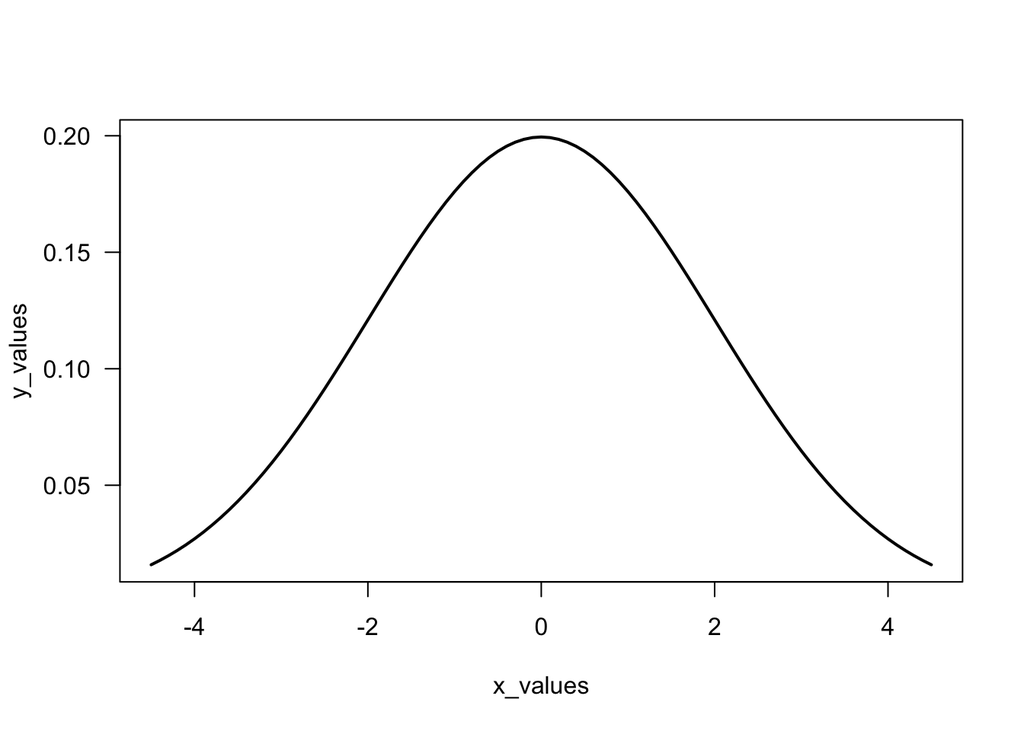

```r
# you should get a plot like this one
x_values <- seq(from = -4.5, to = 4.5, by = 0.1)
y_values <- dnorm(x_values, mean = 0, sd = 2)
plot(x_values, y_values, las = 1, type = "l", lwd = 2)
```

Your turn:

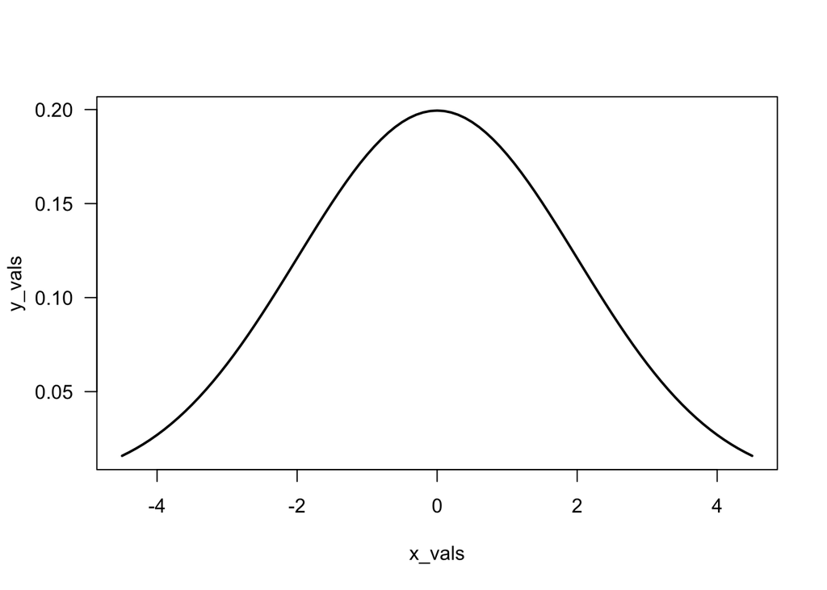

```r
# your code
x_vals <- seq(from = -4.5, to = 4.5, by = 0.1)
y_vals <- gaussian(x_vals, 0, 2)
plot(x_vals, y_vals, las = 1, type = "l", lwd = 2)
```

### Polynomials

In this problem we want to see whether the graph of a given polynomial will cross or touch the *x* axis in a given interval.

Let’s begin with the polynomial: $f(x) = x^2 (x - 1)$. The first thing to do is write a function for the polynomial, for instance:

```r
poly1 <- function(x) {
  (x^2) * (x - 1)
}
```

Once you have a function for the polynomial, you can create a set of pairs of points $x$ and $y = f(x)$, and then use them to graph the polynomial

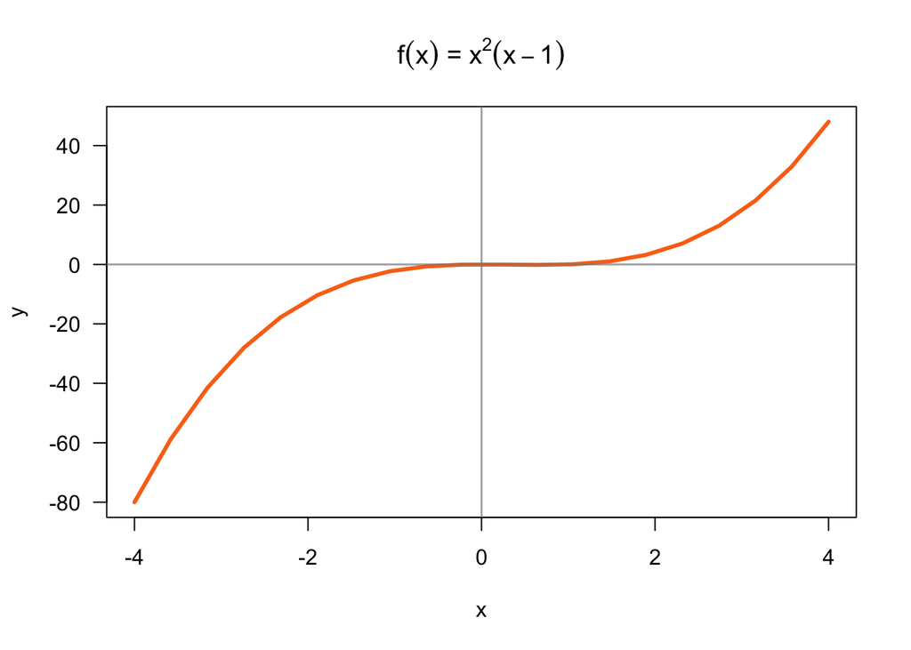

```r
# set of points
x <- seq(-4, 4, length.out = 20)
y <- poly1(x)

# graph polynomial
plot(x, y, type = 'l', lwd = 3, col = "#FB7215", las = 1)
abline(h = 0, v = 0, col = '#888888aa', lwd = 1.5)
title(main = expression(paste(f(x), ' = ', x^2, (x - 1))))
```

Write functions and graph the following polynomials in the x-axis interval -4 to 4:

1. $f(x) = x^3$
2. $f(x) = (x^2 - 1)(x + 3)^3$
3. $f(x) = (x^2 - 1)(x^2 - 9)$

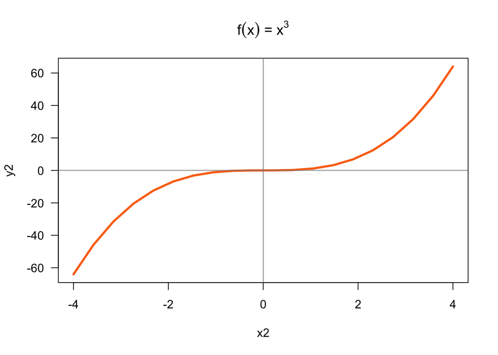

```r
poly2 <- function(x) {
  return(x^3)
}
x2 <- seq(-4, 4, length.out = 20)
y2 <- poly2(x2)
plot(x2, y2, type = 'l', lwd = 3, col = "#FB7215", las = 1)
abline(h = 0, v = 0, col = '#888888aa', lwd = 1.5)
title(main = expression(paste(f(x), ' = ', x^3)))
```

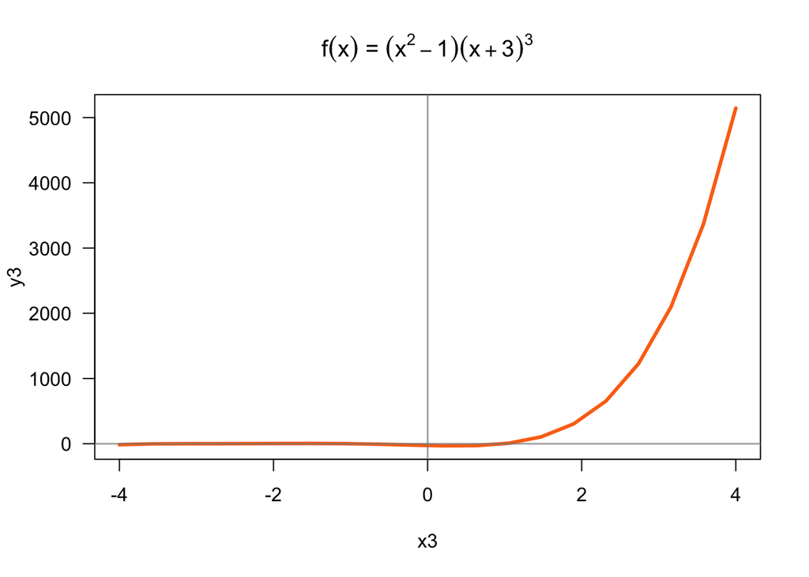

```r
poly3 <- function(x) {
  return((x^2 - 1)*(x + 3)^3)
}
x3 <- seq(-4, 4, length.out = 20)
y3 <- poly3(x3)
plot(x3, y3, type = 'l', lwd = 3, col = "#FB7215", las = 1)
abline(h = 0, v = 0, col = '#888888aa', lwd = 1.5)
title(main = expression(paste(f(x), ' = ', (x^2 - 1)(x+3)^3)))
```

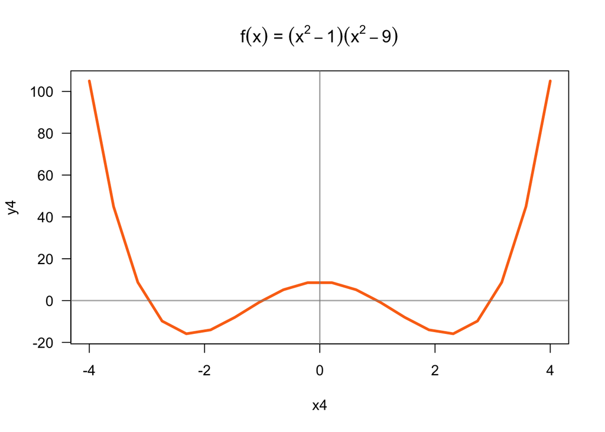

```r
poly4 <- function(x) {
  return((x^2 - 1)*(x^2 - 9))
}
x4 <- seq(-4, 4, length.out = 20)
y4 <- poly4(x4)
plot(x4, y4, type = 'l', lwd = 3, col = "#FB7215", las = 1)
abline(h = 0, v = 0, col = '#888888aa', lwd = 1.5)
title(main = expression(paste(f(x), ' = ', (x^2 - 1), (x^2 - 9))))
```

## Descriptive Statistics

Write a function `descriptive()` that takes a numeric vector as input, and returns a named vector with the following descriptive statistics:

```r
# your descriptive() function
descriptive <- function(vec) {
  # fill in
  min <- min(vec)
  q1 <- median(vec[1:length(vec)/2])
  median <- median(vec)
  mean <- mean(vec)
  q3 <- median(vec[((length(vec)/2) + 1):length(vec)])
  max <- max(vec)
  range <- max - min
  iqr <- q3 - q1
  sd <- sd(vec)
  summary <- c(min = min, q1 = q1, median = median, mean = mean, q3 = q3, max = max, range = range, iqr = iqr, sd = sd)
  return(summary)
}
descriptive(c(1, 2, 3, 4, 5, 6, 7, 8, 9, 10))
```

```
##      min       q1   median     mean       q3      max    range      iqr
##  1.00000  3.00000  5.50000  5.50000  8.00000 10.00000  9.00000  5.00000
##       sd
##  3.02765
```

## Binomial Formula

In lab01 you worked with the formula of the binomial probability:

[figure not shown]

binomial probability

where:

- $n$ is the number of (fixed) trials
- $p$ is the probability of success on each trial
- $1 - p$ is the probability of failure on each trial
- $k$ is a variable that represents the number of successes out of $n$ trials
- the first term in parenthesis is not a fraction, it is the number of combinations in which $k$ success can occur in $n$ trials

R provides the `choose()` function to compute the number of combinations:

[figure not shown]

combinations

For instance, the number of combinations in which $k$ = 2 success can occur in $n$ = 5 trials is:

```r
choose(n = 5, k = 2)
```

```
## [1] 10
```

Combinations are typically expressed in terms of factorials as:

[figure not shown]

combs

Conveniently, R also provides the function `factorial()` to calculate the factorial of an integer:

```r
factorial(4)
```

```
## [1] 24
```

## Your turn: write a binomial function

- Use `factorial()` to create a `combinations()` function. Your function should have arguments `n` and `k`:

```r
# you should be able to call combinations() like this
combinations <- function(k, n) {
  return(factorial(n) / (factorial(k) * factorial(n - k)))
}
combinations(n = 5, k = 2)
```

```
## [1] 10
```

- Use your `combinations()` function to write a `binom_prob()` function that computes binomial probabilities. The arguments should be `n`, `k`, and `prob`. Here’s an example of you should be able to call the function:

```r
# probability of getting 2 successes in 5 trials
# (assuming prob of success = 0.5)
binom_prob <- function(n, k, prob) {
  pr <- combinations(k, n) * (prob^k)*(1-prob)^(n-k)
  return(pr)
}
binom_prob(n = 5, k = 2, prob = 0.5)
```

```
## [1] 0.3125
```

- Use `binom_prob()` to obtain the probability of getting more than 3 heads in 5 tosses with a biased coin of 35% chance of heads.

```r
binom_prob(5, 4, 0.35) + binom_prob(5, 5, 0.35)
```

```
## [1] 0.0540225
```

- Consider rolling a fair die 10 times. Use `binom_prob()` to find the probability of getting exactly 3 sixes?

```r
binom_prob(10, 3, 1/6)
```

```
## [1] 0.1550454
```

## If Conditionals

Write R code that will “squish” a number into the interval [0, 100], so that a number less than 0 is replaced by 0 and a number greater than 100 is replaced by 100.

```r
z <- 100*pi
# Fill in the following if-else statements. You may (or may not)
# have to add or subtract else if or else statements.
if (z > 100) { # Replace TRUE with a condition.
  z <- 100
} else if (z < 0) { # Replace TRUE with a condition.
  z <- 0
}
print(z)
```

```
## [1] 100
```

### Multiple If’s

A common situation involves working with multiple conditions at the same time. You can chain multiple if-else statements:

```r
y <- -1 # Change this value!

if (y > 0) {
  print("positive")
} else if (y < 0) {
  print("negative")
} else {
  print("zero?")
}
```

```
## [1] "negative"
```

## Even number

Write a function `is_even()` that determines whether a number is even (i.e. multiple of 2). If the input number is even, the output should be `TRUE`. If the input number is odd, the output should be `FALSE`. If the input is not a number, the output should be `NA`

Test your function:

```r
is_even <- function(x) {
  if (!is.numeric(x)) {
    return('NA')
  }
  else if (x %% 2 == 0) {
    return(TRUE)
  } else {
    return(TRUE)
  }
}
# even number
is_even(10)

# odd number
is_even(33)

# not a number
is_even('a')
```

[output not shown]

## Odd number

Use your function `is_even()` to write a function `is_odd()` that determines if a number is odd (i.e. not a multiple of 2). If a number is odd, the output should be `TRUE`; if a number is even the output should be `FALSE`; if the input is not a number the output should be `NA`

Test `is_odd()` with the following cases:

```r
is_odd <- function(x) {
  if (!is.numeric(x)) {
    return('NA')
  } else if (is_even(x)) {
    return(FALSE)
  } else {
    return(TRUE)
  }

}
# odd number
is_odd(1)

# even number
is_odd(4)

# not a number
is_odd('a')
```

[output not shown]

## Switch

Working with multiple chained if’s becomes cumbersome. Consider the following example that uses several if’s to convert a day of the week into a number:

```r
# Convert the day of the week into a number.
day <- "Monday" # Change this value!

if (day == 'Sunday') {
  num_day <- 1
} else {
  if (day == "Monday") {
    num_day <- 2
  } else {
    if (day == "Tuesday") {
      num_day <- 3
    } else {
      if (day == "Wednesday") {
        num_day <- 4
      } else {
        if (day == "Thursday") {
          num_day <- 5
        } else {
          if (day == "Friday") {
            num_day <- 6
          } else {
            if (day == "Saturday") {
              num_day <- 7
            }
          }
        }
      }
    }
  }
}


num_day
```

```
## [1] 2
```

Working with several nested if’s like in the example above can be a nigthmare.

In R, you can get rid of many of the braces like this:

```r
# Convert the day of the week into a number.
day <- "Tuesday" # Change this value!

if (day == 'Sunday') {
  num_day <- 1
} else if (day == "Monday") {
  num_day <- 2
} else if (day == "Tuesday") {
  num_day <- 3
} else if (day == "Wednesday") {
  num_day <- 4
} else if (day == "Thursday") {
  num_day <- 5
} else if (day == "Friday") {
  num_day <- 6
} else if (day == "Saturday") {
  num_day <- 7
}

num_day
```

```
## [1] 3
```

### Your turn: a grading function

Write a function `grade()` that takes a `score` argument (i.e. a numeric value between 0 and 100), and returns a letter grade (i.e. character) based on the following grading scheme:

| score | grade |
| --- | --- |
| [90 - 100] | `"A"` |
| [80 - 90) | `"B"` |
| [70 - 80) | `"C"` |
| [60 - 70) | `"D"` |
| < 60 | `"F"` |

You should be able to call your `grade()` function like this:

```r
grade <- function(score) {
  if (score < 0 | score > 100) {
    return("score must be a number between 0 and 100")
  }
  if (score < 60) {
    return("F")
  } else if (score < 70) {
    return("D")
  } else if (score < 80) {
    return("C")
  } else if (score < 90) {
    return("B")
  } else {
    return("A")
  }
}
# grade "A"
grade(score = 90)

# grade "B"
grade(score = 89.9999)

# grade "C"
grade(score = 70.0000001)

# grade "F"
grade(score = 50)
```

[output not shown]

Modify your `grade()` function to include a `stop()` condition when the input `score` value is less than zero or greater than 100. The error message should say something like:

```r
"score must be a number between 0 and 100"
```

```
## [1] "score must be a number between 0 and 100"
```

## The `switch()` function

Consider again the chain of if-then-else’s used to convert a name day into a number dat. We have too many if’s, and there’s a lot of repetition in the code. If you find yourself using many if-else statements with identical structure for slightly different cases, you may want to consider a **switch** statement instead:

```r
# Convert the day of the week into a number.
day <- "Friday" # Change this value!

switch(day, # The expression to be evaluated.
  Sunday = 1,
  Monday = 2,
  Tuesday = 3,
  Wednesday = 4,
  Thursday = 5,
  Friday = 6,
  Saturday = 7,
  NA) # an (optional) default value if there are no matches
```

```
## [1] 6
```

Switch statements can also accept integer arguments, which will act as indices to choose a corresponding element:

```r
# Convert a number into a day of the week.
day_num <- 7 # Change this value!

switch(day_num,
  "Sunday",
  "Monday",
  "Tuesday",
  "Wednesday",
  "Thursday",
  "Friday",
  "Saturday")
```

```
## [1] "Saturday"
```

## Converting Miles to other units

The table below shows the different formulas for converting miles (mi) into other scales:

| Units | Formula |
| --- | --- |
| Inches | mi x 63360 |
| Feet | mi x 5280 |
| Yards | mi x 1760 |
| Meters | mi / 0.00062137 |
| Kms | mi / 0.62137 |

Write the following five functions for each type of conversion. Each function must take one argument `x` with default value: `x = 1`.

- `miles2inches()`
- `miles2feet()`
- `miles2yards()`
- `miles2meters()`
- `miles2kms()`

```r
miles2inches <- function(miles) {
  inches <- miles * 63360
  return(inches)
}

miles2feet <- function(miles) {
  feet <- miles * 5280
  return(feet)
}

miles2yards <- function(miles) {
  yards <- miles * 1760
  return(yards)
}

miles2meters <- function(miles) {
  meters <- miles / 0.00062137
  return(meters)
}
```

For example:

```r
miles2inches(2)
miles2feet(2)
miles2yards(2)
miles2meters(2)
miles2kms(2)
```

[output not shown]

## Using switch()

Create a function `convert()` that converts miles into the specified units. Use `switch()` and the previously defined functions—`miles2inches()`, `miles2feet()`, …, `miles2kms`—to define `convert()`. Use two arguments: `x` and `to`, like this:

```r
convert <- function(miles, to = "km") {
  switch(to,
         'km' = miles2kms(miles),
         'in' = miles2inches(miles),
         'ft' = miles2feet(miles),
         'yd' = miles2yards(miles),
         'm' = miles2meters(miles),
         )
}
convert(40, to = "in")
```

[output not shown]

By default, `to = "km"`, but it can take values such as `"in"`, `"ft"`, `"yd"`, or `"m"`.

Test `convert()` with:

```r
convert(3, "in")
convert(3, "ft")
convert(3, "yd")
convert(3, "m")
convert(3, "km")
```

[output not shown]